# Milestone Report

Henry Bowers

Sunday, March 29, 2015

## Background

The rate of adoption of smartphones and tables is increasing exponentially on a global scale. Texting is a major driver of adoption. Users crave innovations that make texting easier, faster, and more accurate. Mobile device manufacturers that can provide superior texting experiences stand out from their competitors. Text prediction technology - software that predicts the next word a mobile user will type - had strong potential to provide that superior experience.

I initiated the Capstone project to develop a text predictor for mobile devices.This report summarizes the findings of the recently completed exploratory phase of the project.

## Exploration Phase Results

The goal of this phase was to understand what and how much data is required to produce a mobile text predictor for the English language. To achieve this goal I examined text extracts of blogs, news sites, and twitter posts (tweets) on the web.

### Data Analysis

Basic statistics of the data sources follow.

#### News

Lines of text: 77259  
Total words: 2634910  
Mean words per line: 34.1  
Max words per line: 1030  
Min words per line: 1

#### Blogs

Lines of text: 899288  
Total words: 37214743  
Mean words per line: 41.4  
Max words per line: 6629  
Min words per line: 1

#### Twitter

Lines of text: 2360148  
Total words: 29763605  
Mean words per line: 12.6  
Max words per line: 47  
Min words per line: 1

### Text Analysis

I examined the distribution of word sequence frequency across a mixed sample of text from all three data sources.

#### Single-word Sequences

```
## [1] "Num =  13744"
## [1] "Mean =  36.8"
## [1] "Standard Dev =  341"
## [1] "max frequency =  29340"
## [1] "min frequency =  3"
```

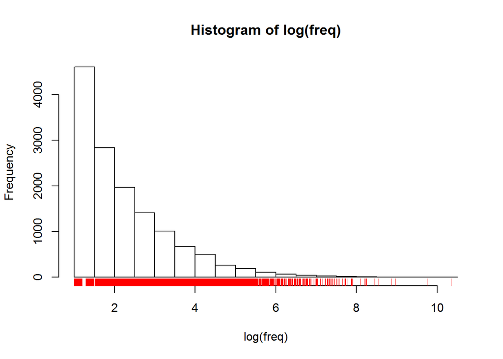

```
## [1] "Most frequent 1-grams:"
```

```
##       term  freq
## 38078  the 29340
## 3824   and 16120
## 42453  you  8478
## 15979  for  7710
## 38060 that  7054
## 41859 with  4732
```

#### Two-word Sequences (bigrams)

```
## [1] "Num =  16178"
## [1] "Mean =  18.3"
## [1] "Standard Dev =  52.1"
## [1] "max frequency =  2618"
## [1] "min frequency =  5"
```

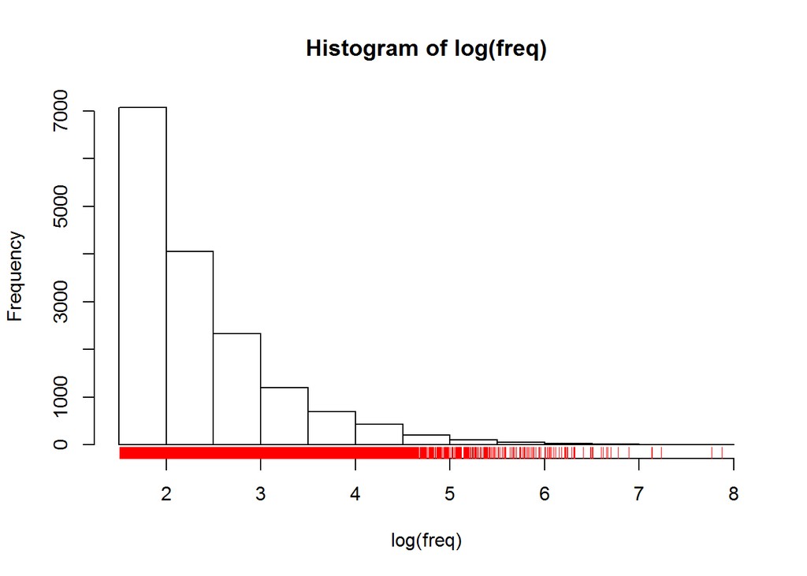

```
## [1] "Most frequent bigrams:"
```

```
##           term freq
## 189076  of the 2618
## 135430  in the 2416
## 101406 for the 1369
## 279483  to the 1336
## 192468  on the 1294
## 276880   to be 1195
```

#### Three-word Sequences (trigrams)

```
## [1] "Num =  14845"
## [1] "Mean =  5.8"
## [1] "Standard Dev =  7.4"
## [1] "max frequency =  233"
## [1] "min frequency =  3"
```

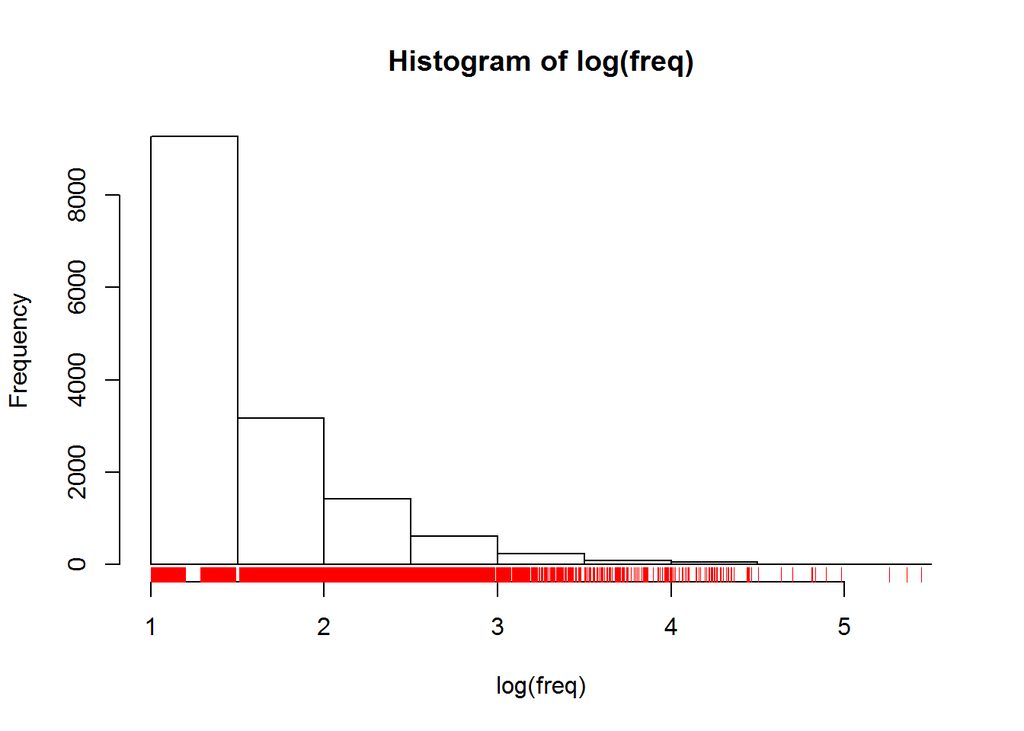

```
## [1] "Most frequent trigrams:"
```

```
##                  term freq
## 413586 thanks for the  233
## 324493     one of the  222
## 11071        a lot of  204
## 459177        to be a  153
## 212761      i want to  136
## 172680    going to be  135
```

## Proposed Prediction Model

Based on the above analysis, my plan is to develop a model to predict the next word in a text message using the last two words typed by the user. Given a two-word sequence, the model will attempt to find the most common three-word sequence that begins with the two words provided. “Most common” will be determined by the relative frequency of three-word sequences in the source data. If the model has no frequency information about the two-word sequence provided (the sequence does not appear in any of the source data used to create the model), the model will attempt to find the most common word that follows the second word in the two-word sequence provided, based on the relative frequency of two-word sequences in the source data.